# Arbre de classification

Cheikh Talla

25/01/2020

# Arbre de décision

Un arbre de décision est un outil d’aide à la décision représentant un ensemble de choix sous la forme graphique d’un arbre. Les différentes décisions possibles sont situées aux extrémités des branches (les « feuilles » de l’arbre), et sont atteintes en fonction de décisions prises à chaque étape. Les arbres de décisions sont des méthodes utilisés dans le cadre où on veut expliquer une variable cible en fonction d’un nombre très important de variables explicatives. Les arbres décisionnels font partie des méthodes d’apprentissage supervisé.

```r
set.seed(101)
alpha     <- 0.7 # percentage of training set
inTrain   <- sample(1:nrow(iris), alpha * nrow(iris))
train.set <- iris[inTrain,]
test.set  <- iris[-inTrain,]
```

```r
#install.packages("rpart")
#install.packages("rpart.plot")
#install.packages("party")
#install.packages("tree")

library("rpart")
library("rpart.plot")
library(tree)

data("iris")
#rpart <- rpart(Species ~ ., data=iris, method="class",)
tree.model <- rpart(Species ~ Sepal.Width + Petal.Width, method="class", data=train.set)
tree.model
```

```
n= 105

node), split, n, loss, yval, (yprob)
      * denotes terminal node

1) root 105 68 virginica (0.31428571 0.33333333 0.35238095)
  2) Petal.Width< 0.8 33  0 setosa (1.00000000 0.00000000 0.00000000) *
  3) Petal.Width>=0.8 72 35 virginica (0.00000000 0.48611111 0.51388889)
    6) Petal.Width< 1.7 38  3 versicolor (0.00000000 0.92105263 0.07894737) *
    7) Petal.Width>=1.7 34  0 virginica (0.00000000 0.00000000 1.00000000) *
```

```r
summary(tree.model)
```

```
Call:
rpart(formula = Species ~ Sepal.Width + Petal.Width, data = train.set,
    method = "class")
  n= 105

         CP nsplit  rel error     xerror       xstd
1 0.4852941      0 1.00000000 1.25000000 0.05917263
2 0.4705882      1 0.51470588 0.92647059 0.07382294
3 0.0100000      2 0.04411765 0.08823529 0.03497757

Variable importance
Petal.Width Sepal.Width
         70          30

Node number 1: 105 observations,    complexity param=0.4852941
  predicted class=virginica   expected loss=0.647619  P(node) =1
    class counts:    33    35    37
   probabilities: 0.314 0.333 0.352
  left son=2 (33 obs) right son=3 (72 obs)
  Primary splits:
      Petal.Width < 0.8  to the left,  improve=33.95159, (0 missing)
      Sepal.Width < 3.35 to the right, improve=12.63677, (0 missing)
  Surrogate splits:
      Sepal.Width < 3.35 to the right, agree=0.838, adj=0.485, (0 split)

Node number 2: 33 observations
  predicted class=setosa      expected loss=0  P(node) =0.3142857
    class counts:    33     0     0
   probabilities: 1.000 0.000 0.000

Node number 3: 72 observations,    complexity param=0.4705882
  predicted class=virginica   expected loss=0.4861111  P(node) =0.6857143
    class counts:     0    35    37
   probabilities: 0.000 0.486 0.514
  left son=6 (38 obs) right son=7 (34 obs)
  Primary splits:
      Petal.Width < 1.7  to the left,  improve=30.44591, (0 missing)
      Sepal.Width < 2.95 to the left,  improve= 5.54798, (0 missing)
  Surrogate splits:
      Sepal.Width < 2.95 to the left,  agree=0.708, adj=0.382, (0 split)

Node number 6: 38 observations
  predicted class=versicolor  expected loss=0.07894737  P(node) =0.3619048
    class counts:     0    35     3
   probabilities: 0.000 0.921 0.079

Node number 7: 34 observations
  predicted class=virginica   expected loss=0  P(node) =0.3238095
    class counts:     0     0    34
   probabilities: 0.000 0.000 1.000
```

### Représentation graphique

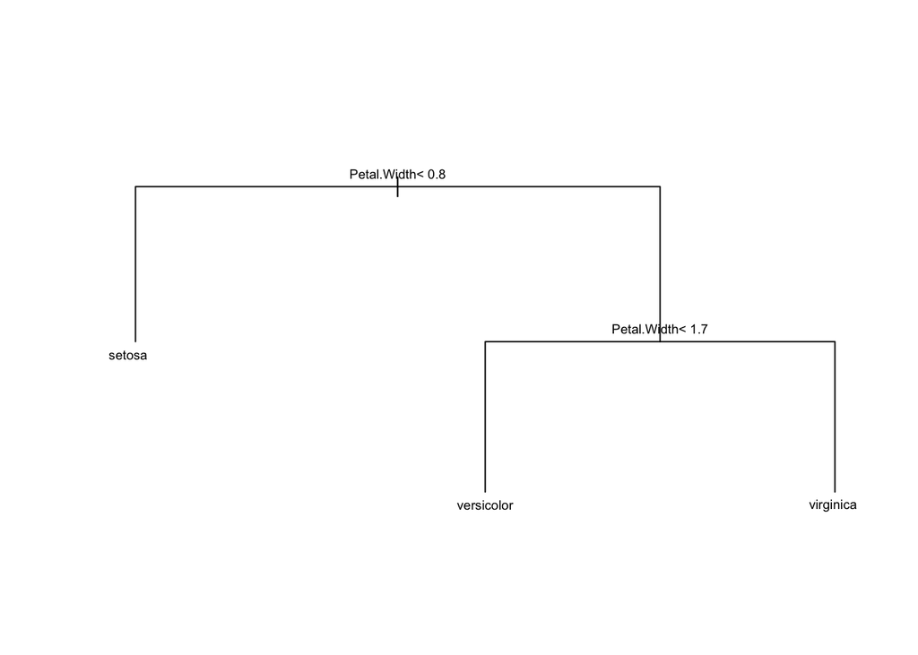

```r
plot(tree.model, ylim=c(0,1.2))
text(tree.model, cex=0.6)
library(party)
```

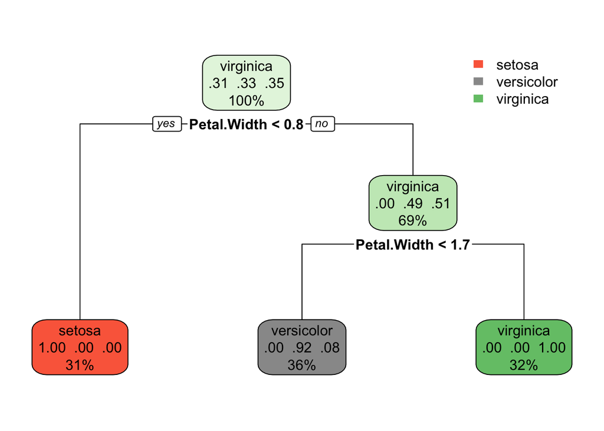

```r
rpart.plot(tree.model)
```

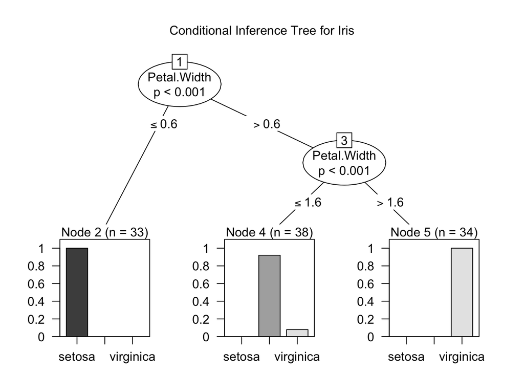

```r
fit <- ctree(Species ~ Sepal.Width + Petal.Width,  data=train.set)
plot(fit, main="Conditional Inference Tree for Iris")
```

Les partitions sont définies par l’arbre de classification ci-dessous. Par exemple, le premier nœud divise chaque espèce avec une largeur de pétale <0.8 en setosa. Ensuite, toutes les espèces avec une largeur de pétale > 1.75 sont virginica et ainsi de suite.

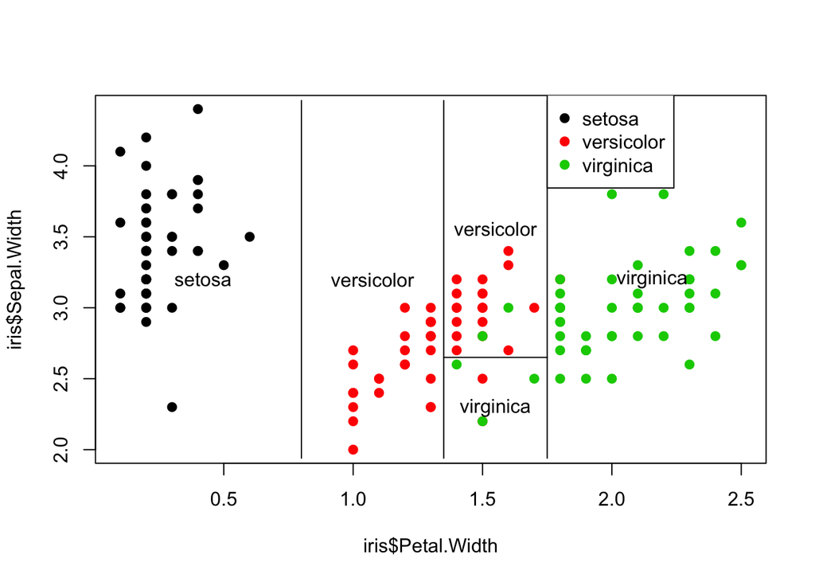

```r
tree <- tree(Species ~ Sepal.Width + Petal.Width,  data=iris)
plot(iris$Petal.Width,iris$Sepal.Width,pch=19,col=as.numeric(iris$Species))
partition.tree(tree,label="Species",add=TRUE)
legend(1.75,4.5,legend=unique(iris$Species),col=unique(as.numeric(iris$Species)),pch=19)
```

### Prédiction

Maintenant que notre modèle est construit, nous devons vérifier sa capacité prédictive en le comparant à des données de test. Nous utilisons donc la fonction **predict** pour prédire les classes des données de test. Et puis créez une matrice montrant la comparaison entre le résultat de la prédiction et les données réelles.

```r
# prediction
my.prediction <- predict(tree.model, test.set) # gives the probability for each class
head(my.prediction)
```

```
   setosa versicolor virginica
1       1          0         0
5       1          0         0
11      1          0         0
13      1          0         0
16      1          0         0
23      1          0         0
```

```r
my <- ifelse(my.prediction<0.5,0,1)
Res <- ifelse(my[,1]==1,"setosa",ifelse(my[,2]==1,"versicolor","virginica"))
table(Res, test.set$Species)
```

```
Res          setosa versicolor virginica
  setosa         17          0         0
  versicolor      0         14         2
  virginica       0          1        11
```

## Simplification de l’arbre

### Niveaux de simplification

la valeur d’un paramètre de complexité noté **cp** ; en guise de première approche, disons que plus le cp est petit, plus grand est l’arbre de régression.

La commande ci-dessous donne le coefficient de complexité optimal.

La valeur optimale pour cp est celle qui minimise l’erreur relative. Le graphique nous indique que cette valeur est proche de cp = 0.065.

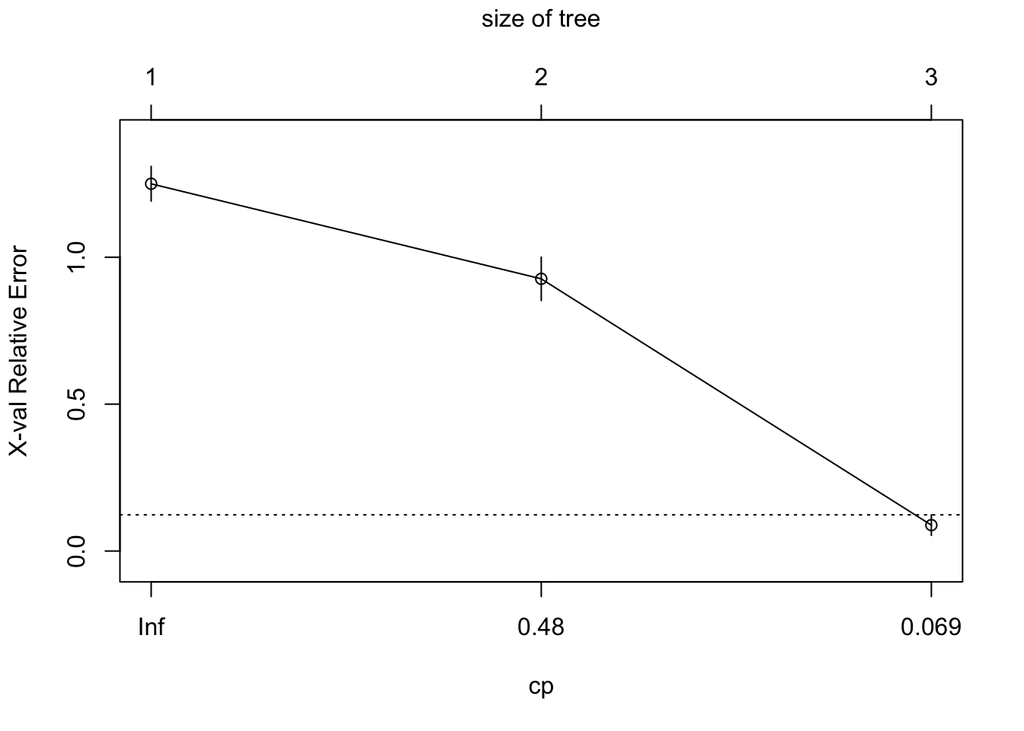

```r
plotcp(tree.model)
```

### Élagage

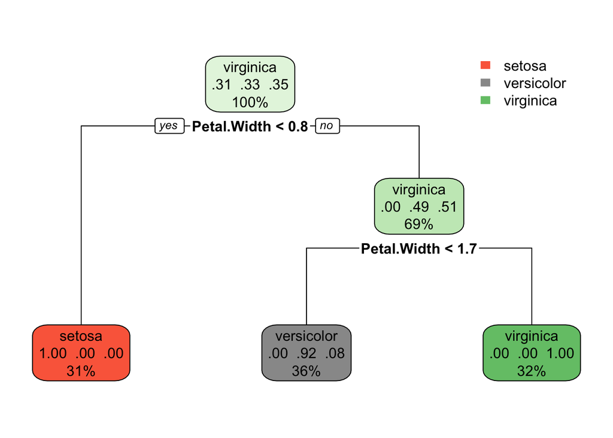

```r
arbre2 = prune(tree.model, cp = 0.065)
rpart.plot(arbre2)
```

La taille d’un arbre de décision modifie souvent la précision de la prédiction. En général, un arbre plus grand signifie une précision plus élevée, mais si l’arbre est trop grand, il peut aussi poser des problèmes de précision et de robustesss. La robustesse signifie la cohérence des performances de l’arbre. Par conséquent, l’objectif serait de faire pousser un arbre à une taille optimale suffisamment précise et robuste.

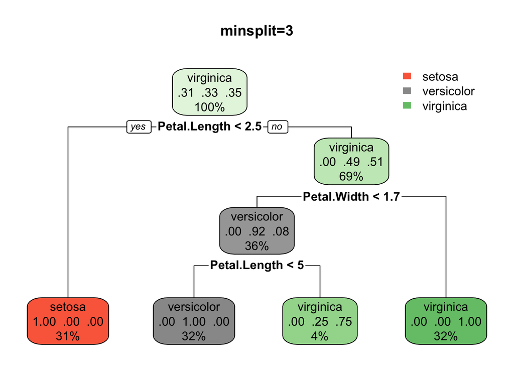

```r
target = Species ~ Sepal.Length + Sepal.Width + Petal.Length + Petal.Width
tree_ms3 = rpart(target,  train.set, control = rpart.control(minsplit = 3))
tree_ms10 = rpart(target, train.set, control = rpart.control(minsplit = 10))

par(mfrow = c(1, 1))
rpart.plot(tree_ms3, main = "minsplit=3")
```

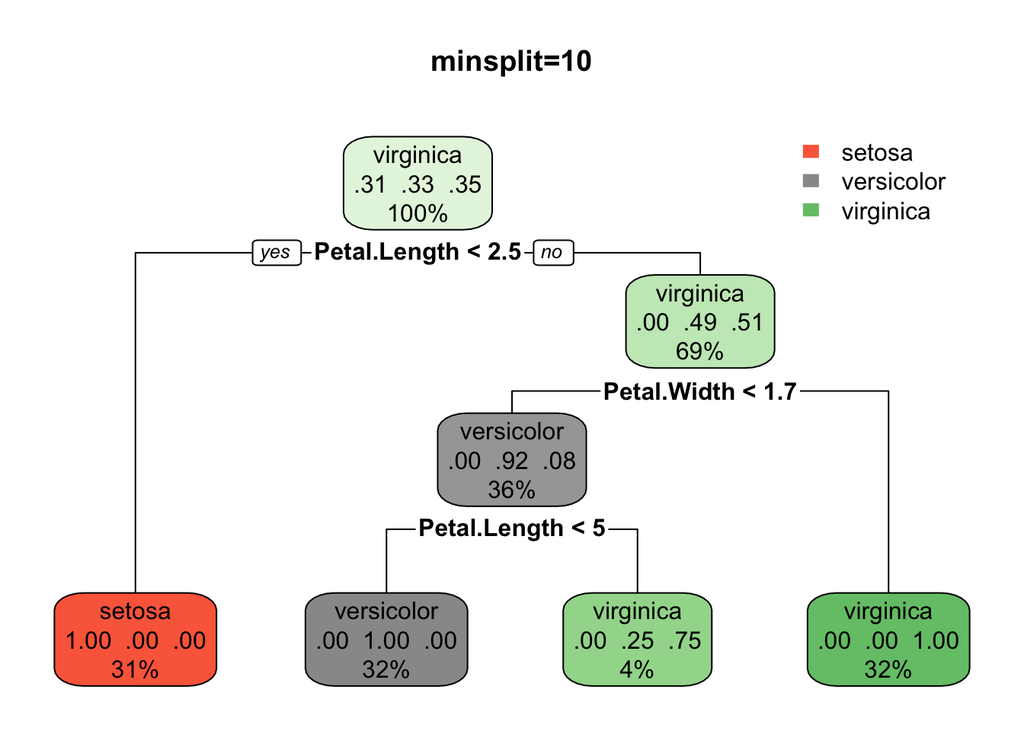

```r
#text(tree_ms3, cex = 0.7)
rpart.plot(tree_ms10, main = "minsplit=10")
```

```r
#text(tree_ms10, cex = 0.7)
```

**minsplit**: fait référence au nombre minimum de points de données requis avant qu’une division soit effectuée sur un nœud.

### Régression linéaire et arbre de classification

1. Si la relation entre la variable explicative et la variable à expliquer est bien approximée par un modèle linéaire, la régression linéaire surclassera le modèle basé sur un arbre de classification.
2. S’il existe une non-linéarité et une relation complexe entre les variables explicatives et les variables à expliquer, un modèle d’arbre de classification surclassera une méthode de régression classique.
3. Un modèle d’arbre de décision est plus facile à expliquer qu’un modèle linéaire. Les modèles d’arbre de décision sont encore plus simples à interpréter que la régression linéaire!

### Erreur de classement

```r
mc <- table(Res, test.set$Species)
erreur.classement<-1.0-(mc[1,1]+mc[2,2]+mc[3,3])/sum(mc)
print(erreur.classement)
```

```
[1] 0.06666667
```

### Taux de prédiction

```r
# versicolor
prediction=mc[2,2]/sum(mc[2,])
print(prediction)
```

```
[1] 0.875
```